# Explanatory Data Analysis of Global Video Game Sales

Module: M504A AI and Applications (WS1225)

Assessment: Individual Project

Student: GH1056684 - Zainab Awad Alzubair Mohammed

**Dataset Source:** https://www.kaggle.com/datasets/gregorut/videogamesales

## 1. Business Context

In this project, I act as a data science consultant for a video game company that seeks to gain better insights into the global video game market. The video game company is interested in learning which video game genres, platforms, publishers, and regions achieve the highest sales. This information can be used to inform business decisions regarding video game development, platforms to use for development, and regional marketing and launch planning.

The dataset used for this analysis contains historical video game sales data, including game titles, platforms, years of release, genres, publishers, and sales for North America, Europe, Japan, and worldwide. By analyzing this data set, the video game company can gain better insights into the market and use this knowledge to inform its business decisions.

The purpose of this notebook is to create an explanatory data analysis pipeline that analyzes and answers business questions based on the data set using Python and Pandas.

```python
!mamba install pandas
```

```
/bin/bash: line 1: mamba: command not found
```

## Import Libraries and Read the dataset

```python
import pandas as pd
import matplotlib.pyplot as plt

df = pd.read_csv("./vgsales.csv")
df.head()
```

|  | Rank | Name | Platform | Year | Genre | Publisher | NA_Sales | EU_Sales | JP_Sales | Other_Sales | Global_Sales |
| --- | --- | --- | --- | --- | --- | --- | --- | --- | --- | --- | --- |
| 0 | 1 | Wii Sports | Wii | 2006.0 | Sports | Nintendo | 41.49 | 29.02 | 3.77 | 8.46 | 82.74 |
| 1 | 2 | Super Mario Bros. | NES | 1985.0 | Platform | Nintendo | 29.08 | 3.58 | 6.81 | 0.77 | 40.24 |
| 2 | 3 | Mario Kart Wii | Wii | 2008.0 | Racing | Nintendo | 15.85 | 12.88 | 3.79 | 3.31 | 35.82 |
| 3 | 4 | Wii Sports Resort | Wii | 2009.0 | Sports | Nintendo | 15.75 | 11.01 | 3.28 | 2.96 | 33.00 |
| 4 | 5 | Pokemon Red/Pokemon Blue | GB | 1996.0 | Role-Playing | Nintendo | 11.27 | 8.89 | 10.22 | 1.00 | 31.37 |

## 2. Dataset Overview

The dataset is related to historical video game sales. The dataset is in the form of rows containing information about individual video game titles. Some of the important columns in this dataset include video game titles, platforms, years of release, genre, publishers, and sales in various markets.

I chose this dataset because it is suitable for analyzing individual products as well as markets. With this dataset, it is possible to analyze various video game genres, platforms in video game sales, and player behavior in various markets.

## Data Exploration and Inspection

```python
#explore the data
df.shape
df.columns
df.info()
df.describe(include="all")
```

```
<class 'pandas.core.frame.DataFrame'>
RangeIndex: 16598 entries, 0 to 16597
Data columns (total 11 columns):
 #   Column        Non-Null Count  Dtype
---  ------        --------------  -----
 0   Rank          16598 non-null  int64
 1   Name          16598 non-null  object
 2   Platform      16598 non-null  object
 3   Year          16327 non-null  float64
 4   Genre         16598 non-null  object
 5   Publisher     16540 non-null  object
 6   NA_Sales      16598 non-null  float64
 7   EU_Sales      16598 non-null  float64
 8   JP_Sales      16598 non-null  float64
 9   Other_Sales   16598 non-null  float64
 10  Global_Sales  16598 non-null  float64
dtypes: float64(6), int64(1), object(4)
memory usage: 1.4+ MB
```

|  | Rank | Name | Platform | Year | Genre | Publisher | NA_Sales | EU_Sales | JP_Sales | Other_Sales | Global_Sales |
| --- | --- | --- | --- | --- | --- | --- | --- | --- | --- | --- | --- |
| count | 16598.000000 | 16598 | 16598 | 16327.000000 | 16598 | 16540 | 16598.000000 | 16598.000000 | 16598.000000 | 16598.000000 | 16598.000000 |
| unique | NaN | 11493 | 31 | NaN | 12 | 578 | NaN | NaN | NaN | NaN | NaN |
| top | NaN | Need for Speed: Most Wanted | DS | NaN | Action | Electronic Arts | NaN | NaN | NaN | NaN | NaN |
| freq | NaN | 12 | 2163 | NaN | 3316 | 1351 | NaN | NaN | NaN | NaN | NaN |
| mean | 8300.605254 | NaN | NaN | 2006.406443 | NaN | NaN | 0.264667 | 0.146652 | 0.077782 | 0.048063 | 0.537441 |
| std | 4791.853933 | NaN | NaN | 5.828981 | NaN | NaN | 0.816683 | 0.505351 | 0.309291 | 0.188588 | 1.555028 |
| min | 1.000000 | NaN | NaN | 1980.000000 | NaN | NaN | 0.000000 | 0.000000 | 0.000000 | 0.000000 | 0.010000 |
| 25% | 4151.250000 | NaN | NaN | 2003.000000 | NaN | NaN | 0.000000 | 0.000000 | 0.000000 | 0.000000 | 0.060000 |
| 50% | 8300.500000 | NaN | NaN | 2007.000000 | NaN | NaN | 0.080000 | 0.020000 | 0.000000 | 0.010000 | 0.170000 |
| 75% | 12449.750000 | NaN | NaN | 2010.000000 | NaN | NaN | 0.240000 | 0.110000 | 0.040000 | 0.040000 | 0.470000 |
| max | 16600.000000 | NaN | NaN | 2020.000000 | NaN | NaN | 41.490000 | 29.020000 | 10.220000 | 10.570000 | 82.740000 |

```python
#check the null values
df.isnull().sum()
```

|  | 0 |
| --- | --- |
| Rank | 0 |
| Name | 0 |
| Platform | 0 |
| Year | 271 |
| Genre | 0 |
| Publisher | 58 |
| NA_Sales | 0 |
| EU_Sales | 0 |
| JP_Sales | 0 |
| Other_Sales | 0 |
| Global_Sales | 0 |

**dtype:** int64

```python
df.duplicated().sum()
```

```
np.int64(0)
```

```python
df["Genre"].value_counts()
```

| Genre | count |
| --- | --- |
| Action | 3316 |
| Sports | 2346 |
| Misc | 1739 |
| Role-Playing | 1488 |
| Shooter | 1310 |
| Adventure | 1286 |
| Racing | 1249 |
| Platform | 886 |
| Simulation | 867 |
| Fighting | 848 |
| Strategy | 681 |
| Puzzle | 582 |

**dtype:** int64

```python
df["Platform"].value_counts().head(10)
```

| Platform | count |
| --- | --- |
| DS | 2163 |
| PS2 | 2161 |
| PS3 | 1329 |
| Wii | 1325 |
| X360 | 1265 |
| PSP | 1213 |
| PS | 1196 |
| PC | 960 |
| XB | 824 |
| GBA | 822 |

**dtype:** int64

```python
df["Year"].describe()
```

|  | Year |
| --- | --- |
| count | 16327.000000 |
| mean | 2006.406443 |
| std | 5.828981 |
| min | 1980.000000 |
| 25% | 2003.000000 |
| 50% | 2007.000000 |
| 75% | 2010.000000 |
| max | 2020.000000 |

**dtype:** float64

The dataset has a large number of records with multiple variables, including the game name, platform, year, genre, publisher, and regional sales. By using `df.shape`, `df.info`, and `df.describe`, the dataset can be examined to understand the presence of different kinds of variables, including numerical and categorical data, which can be used for different kinds of analysis and comparison.

By using `df.isnull()`.sum, the missing values can be identified, which shows that the dataset has missing values for the Year and Publisher columns, while other columns have no missing values. The missing values for the Year column must be taken care of during the preprocessing of the dataset, as the Year column is very important for the analysis of trends.

The dataset has no duplicate rows (0 duplicates), which means that the dataset is consistent and no preprocessing is required for removing duplicates.

Looking at the distribution of these categories, it is clear that there is some variation in terms of how often certain genres appear in comparison to others. For instance, in the Genre column, there is a range of different categories such as Action, Sports, Shooter, among others. Similarly, in the Platform column, there is also significant variation in terms of how often certain platforms appear in comparison to others. This indicates that perhaps some platforms had significantly more game releases. Looking at the Year column, I think it is clear that most of the games were released within a particular time range. However, there is some variation in terms of year. This is an indication that perhaps this dataset is showing historical trends rather than current information.

Overall, it is clear that this dataset is suitable for analysis after cleaning it of missing values in certain columns. Additionally, it gives an initial idea of how games are distributed in terms of genre, platforms, among other factors.

## Data Cleaning

I performed a Preprocessing of the data because it is important to ensure that the analysis is valid. For instance, missing values and incorrect data types can lead to incorrect conclusions. For this project, I cleaned the data by removing missing values for some columns and converting the year to its integer form.

```python
#convert year to the integer form
df_clean = df.dropna(subset=["Year", "Publisher"]).copy()
df_clean["Year"] = df_clean["Year"].astype(int)
df_clean.shape
```

```
(16291, 11)
```

```python
df_clean.isnull().sum()
```

|  | 0 |
| --- | --- |
| Rank | 0 |
| Name | 0 |
| Platform | 0 |
| Year | 0 |
| Genre | 0 |
| Publisher | 0 |
| NA_Sales | 0 |
| EU_Sales | 0 |
| JP_Sales | 0 |
| Other_Sales | 0 |
| Global_Sales | 0 |

**dtype:** int64

```python
df_clean.head()
```

|  | Rank | Name | Platform | Year | Genre | Publisher | NA_Sales | EU_Sales | JP_Sales | Other_Sales | Global_Sales |
| --- | --- | --- | --- | --- | --- | --- | --- | --- | --- | --- | --- |
| 0 | 1 | Wii Sports | Wii | 2006 | Sports | Nintendo | 41.49 | 29.02 | 3.77 | 8.46 | 82.74 |
| 1 | 2 | Super Mario Bros. | NES | 1985 | Platform | Nintendo | 29.08 | 3.58 | 6.81 | 0.77 | 40.24 |
| 2 | 3 | Mario Kart Wii | Wii | 2008 | Racing | Nintendo | 15.85 | 12.88 | 3.79 | 3.31 | 35.82 |
| 3 | 4 | Wii Sports Resort | Wii | 2009 | Sports | Nintendo | 15.75 | 11.01 | 3.28 | 2.96 | 33.00 |
| 4 | 5 | Pokemon Red/Pokemon Blue | GB | 1996 | Role-Playing | Nintendo | 11.27 | 8.89 | 10.22 | 1.00 | 31.37 |

After cleaning, the data is now ready for analysis. Removing data where there is no year value is justified because year is an essential attribute for performing trend analysis. Converting the year attribute to integer type makes it easier for grouping and plotting.

## Business Questions

**1- Which genres generate the highest global sales?**

This question is important because genres play a big role in determining the success of a product. If some genres perform better than others in terms of sales, the company may focus on those genres when developing new games.

```python
genre_sales = df_clean.groupby("Genre")["Global_Sales"].sum().sort_values(ascending=False)
genre_sales
```

| Genre | Global_Sales |
| --- | --- |
| Action | 1722.84 |
| Sports | 1309.24 |
| Shooter | 1026.20 |
| Role-Playing | 923.83 |
| Platform | 829.13 |
| Misc | 789.87 |
| Racing | 726.76 |
| Fighting | 444.05 |
| Simulation | 389.98 |
| Puzzle | 242.21 |
| Adventure | 234.59 |
| Strategy | 173.27 |

**dtype:** float64

```python
genre_sales = df_clean.groupby("Genre")["Global_Sales"].sum().sort_values(ascending=False)
genre_sales
```

| Genre | Global_Sales |
| --- | --- |
| Action | 1722.84 |
| Sports | 1309.24 |
| Shooter | 1026.20 |
| Role-Playing | 923.83 |
| Platform | 829.13 |
| Misc | 789.87 |
| Racing | 726.76 |
| Fighting | 444.05 |
| Simulation | 389.98 |
| Puzzle | 242.21 |
| Adventure | 234.59 |
| Strategy | 173.27 |

**dtype:** float64

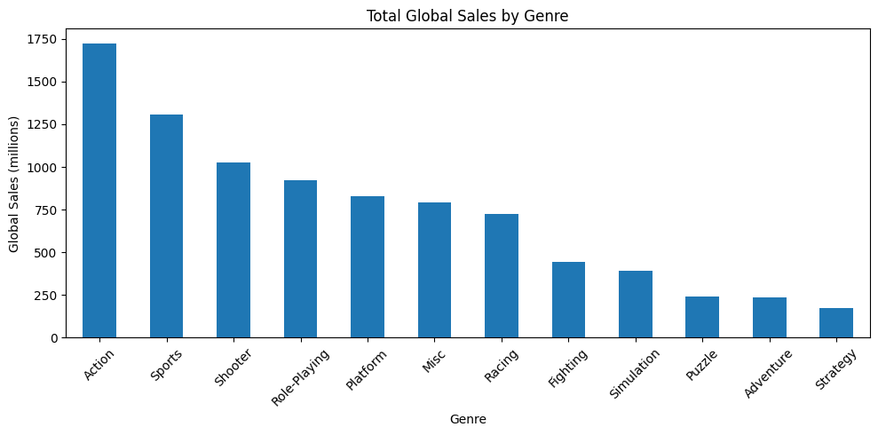

```python
genre_sales.plot(kind="bar", figsize=(10,5))
plt.title("Total Global Sales by Genre")
plt.xlabel("Genre")
plt.ylabel("Global Sales (millions)")
plt.xticks(rotation=45)
plt.tight_layout()
plt.show()
```

The above analysis shows that the highest-selling genre is Action, with 1722.84 million units sold, followed by Sports, with 1309.24 million units sold, and then Shooter, with 1026.20 million units sold. This shows that the highest demand is for action and competitive games, and hence the genre of the games should be focused on by the company.

**2- Which platforms are the most successful in terms of global sales?**

This question matters because the platform on which the game is released has a direct influence on the level of exposure, the size of the audience, and the revenue generated. This is, therefore, an important business decision.

```python
# Group games by platform and calculate total global sales
platform_sales = df_clean.groupby("Platform")["Global_Sales"].sum().sort_values(ascending=False)
platform_sales.head(10)
```

| Platform | Global_Sales |
| --- | --- |
| PS2 | 1233.46 |
| X360 | 969.60 |
| PS3 | 949.35 |
| Wii | 909.81 |
| DS | 818.91 |
| PS | 727.39 |
| GBA | 305.62 |
| PSP | 291.71 |
| PS4 | 278.10 |
| PC | 254.70 |

**dtype:** float64

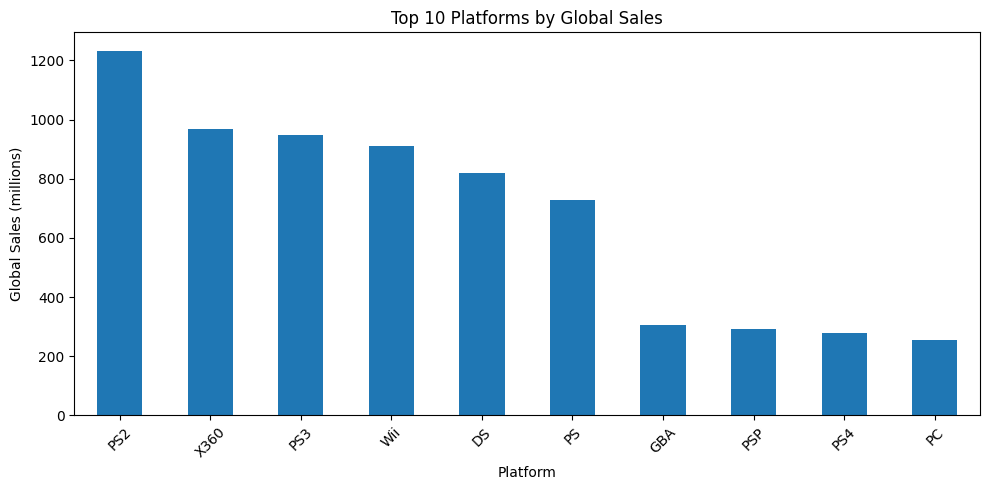

```python
# Plot top 10-performing platforms
platform_sales.head(10).plot(kind="bar", figsize=(10,5))
plt.title("Top 10 Platforms by Global Sales")
plt.xlabel("Platform")
plt.ylabel("Global Sales (millions)")
plt.xticks(rotation=45)
plt.tight_layout()
plt.show()
```

The results show that PS2 is the best platform in terms of success, with 1233.46M in sales, followed by X360 at 969.60M and PS3 at 949.35M. This suggests that the top console platforms yield more money for the companies. Hence, it is important for companies to focus on releasing games for top console platforms.

**3- How do sales differ across North America, Europe, and Japan?**

In the video game industry, regional preferences are very important. A video game may perform well in one region, but the same game may not perform well in another.

```python
# Sum total sales for each region
regional_totals = df_clean[["NA_Sales", "EU_Sales", "JP_Sales"]].sum().sort_values(ascending=False)
# Display regional totals
regional_totals
```

|  | 0 |
| --- | --- |
| NA_Sales | 4327.65 |
| EU_Sales | 2406.69 |
| JP_Sales | 1284.27 |

**dtype:** float64

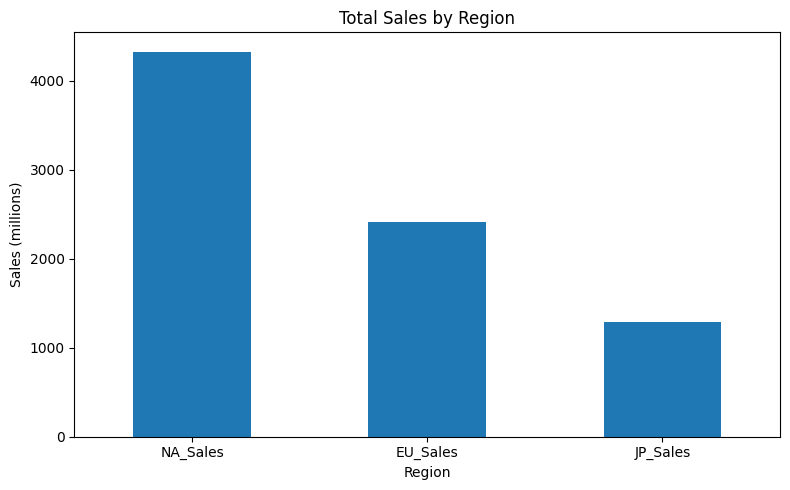

```python
# Plot sales comparison by region
regional_totals.plot(kind="bar", figsize=(8,5))
plt.title("Total Sales by Region")
plt.xlabel("Region")
plt.ylabel("Sales (millions)")
plt.xticks(rotation=0)
plt.tight_layout()
plt.show()
```

The largest market is North America, which generates 4327.65M in sales, followed by Europe, which generates 2406.69M, and Japan, which generates 1284.27M. This is an indication that North America is contributing the greatest demand. Hence, this market should be focused on while adjusting strategies for other markets.

**4- Which publishers dominate the market?**

Publisher analysis can be useful for competitive benchmarking. By determining which publishers are the most successful, the company can gain insight into who the major competitors are and what level of performance is achievable in the marketplace.

```python
# Group games by publisher and calculate total global sales
publisher_sales = df_clean.groupby("Publisher")["Global_Sales"].sum().sort_values(ascending=False)
# Display top 10 publishers
publisher_sales.head(10)
```

| Publisher | Global_Sales |
| --- | --- |
| Nintendo | 1784.43 |
| Electronic Arts | 1093.39 |
| Activision | 721.41 |
| Sony Computer Entertainment | 607.28 |
| Ubisoft | 473.54 |
| Take-Two Interactive | 399.30 |
| THQ | 340.44 |
| Konami Digital Entertainment | 278.56 |
| Sega | 270.70 |
| Namco Bandai Games | 253.65 |

**dtype:** float64

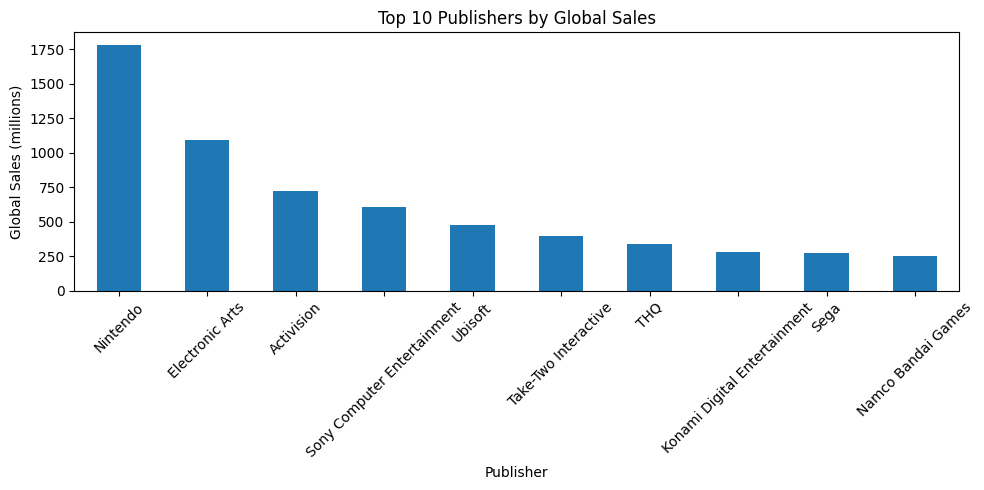

```python
# Plot top publishers
publisher_sales.head(10).plot(kind="bar", figsize=(10,5))
plt.title("Top 10 Publishers by Global Sales")
plt.xlabel("Publisher")
plt.ylabel("Global Sales (millions)")
plt.xticks(rotation=45)
plt.tight_layout()
plt.show()
```

The top publishers have much higher total sales than the rest, which shows a high level of concentration of power in the industry. This, therefore, shows that the industry is dominated by established publishers, which means that new companies must compete with strong brands or look for niche opportunities.

**5- How have global video game sales changed over time?**

Trend analysis can help the company understand the history of the gaming industry. This can help to identify periods of growth, peak, or decline, which can be strategically interpreted.

```python
# Calculate total global sales per year
yearly_sales = df_clean.groupby("Year")["Global_Sales"].sum()
# Display first few rows
yearly_sales.head()
```

| Year | Global_Sales |
| --- | --- |
| 1980 | 11.38 |
| 1981 | 35.77 |
| 1982 | 28.86 |
| 1983 | 16.79 |
| 1984 | 50.36 |

**dtype:** float64

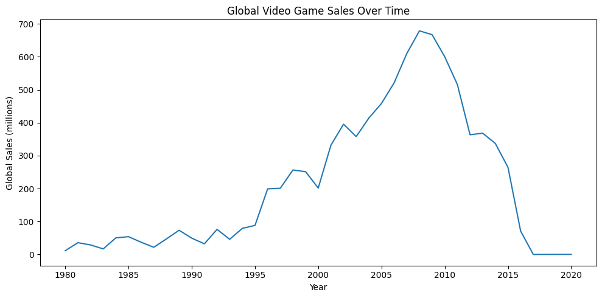

```python
# Plot sales trend over time
yearly_sales.plot(figsize=(10,5))
plt.title("Global Video Game Sales Over Time")
plt.xlabel("Year")
plt.ylabel("Global Sales (millions)")
plt.tight_layout()
plt.show()
```

The sales increase over time and reach a peak period before decreasing in later years. This implies that the gaming industry has gone through a period of growth and later some changes in the market. It is important to understand that the success in the past should be carefully considered in making decisions for the future.

**6- Which genre performs best in each region?**

This question is important because the audience of each region may have different preferences for game genres. Understanding these differences may help the company develop products for specific regions.

```python
# Compare genre performance across regions
genre_region = df_clean.groupby("Genre")[["NA_Sales", "EU_Sales", "JP_Sales"]].sum()
# Display results
genre_region
```

| Genre | NA_Sales | EU_Sales | JP_Sales |
| --- | --- | --- | --- |
| Action | 861.77 | 516.48 | 158.65 |
| Adventure | 101.93 | 63.74 | 51.99 |
| Fighting | 220.74 | 100.00 | 87.15 |
| Misc | 396.92 | 211.77 | 106.67 |
| Platform | 445.99 | 200.65 | 130.65 |
| Puzzle | 122.01 | 50.52 | 56.68 |
| Racing | 356.93 | 236.31 | 56.61 |
| Role-Playing | 326.50 | 187.57 | 350.29 |
| Shooter | 575.16 | 310.45 | 38.18 |
| Simulation | 181.78 | 113.02 | 63.54 |
| Sports | 670.09 | 371.34 | 134.76 |
| Strategy | 67.83 | 44.84 | 49.10 |

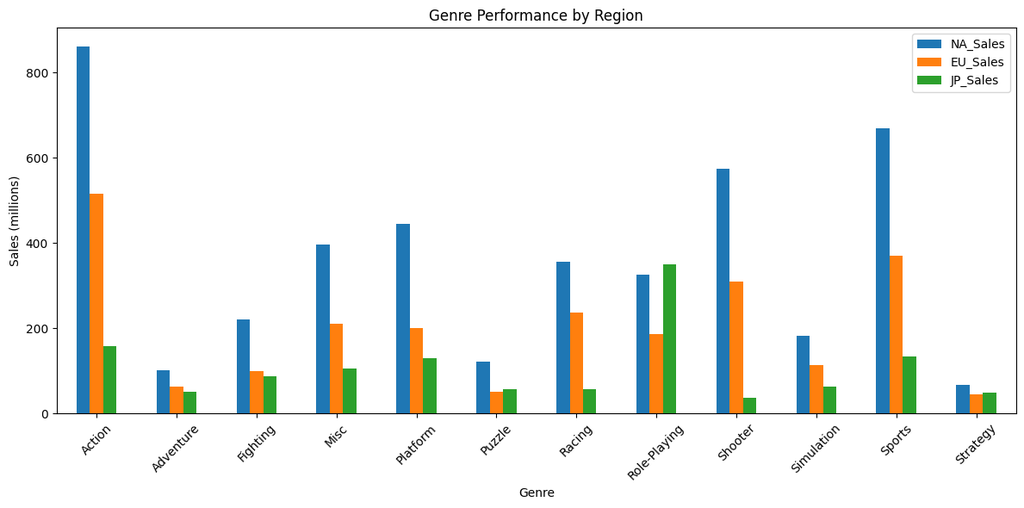

```python
# Plot genre performance by region
genre_region.plot(kind="bar", figsize=(12,6))
plt.title("Genre Performance by Region")
plt.xlabel("Genre")
plt.ylabel("Sales (millions)")
plt.xticks(rotation=45)
plt.tight_layout()
plt.show()
```

The results show that genre performance varies by region, although some genres have high performance across regions. This suggests that players' preferences are not the same all over the world. So, game companies should tailor their game and marketing strategies by region.

**7- Which platform and genre combinations are the most successful?**

A game’s success is affected not only by its genre or platform independently, but also jointly. This question is useful to identify which market combinations are best for future planning.

```python
# Calculate total sales for each platform and genre combination
platform_genre = (
    df_clean.groupby(["Platform", "Genre"])["Global_Sales"]
    .sum()
    .sort_values(ascending=False)
)# Display top combinations
platform_genre.head(15)
```

| Platform | Genre | Global_Sales |
| --- | --- | --- |
| PS3 | Action | 304.02 |
| Wii | Sports | 289.95 |
| X360 | Shooter | 277.23 |
| PS2 | Action | 272.43 |
|  | Sports | 262.64 |
| X360 | Action | 239.67 |
| Wii | Misc | 217.43 |
| PS3 | Shooter | 195.80 |
| PS2 | Racing | 154.21 |
| DS | Misc | 137.67 |
| X360 | Sports | 137.43 |
| PS3 | Sports | 134.91 |
| DS | Simulation | 131.65 |
|  | Role-Playing | 126.56 |
| PS | Action | 125.74 |

**dtype:** float64

The top combinations of platform and genre produce considerably higher sales than the rest, which proves that the success of a game is a combination of the two factors. This shows that some games perform better in certain platforms than in others. Therefore, the genre of the game should match the most appropriate platform.

**8- Are newer games more successful than older games?**

This question seeks to understand whether the success of games has increased or decreased over the years on average. It helps the company understand whether the market has become more competitive or whether the average sales of games have changed over the years.

```python
# Calculate average global sales per game by year
avg_sales_by_year = df_clean.groupby("Year")["Global_Sales"].mean()
# Display first few values
avg_sales_by_year.head()
```

| Year | Global_Sales |
| --- | --- |
| 1980 | 1.264444 |
| 1981 | 0.777609 |
| 1982 | 0.801667 |
| 1983 | 0.987647 |
| 1984 | 3.597143 |

**dtype:** float64

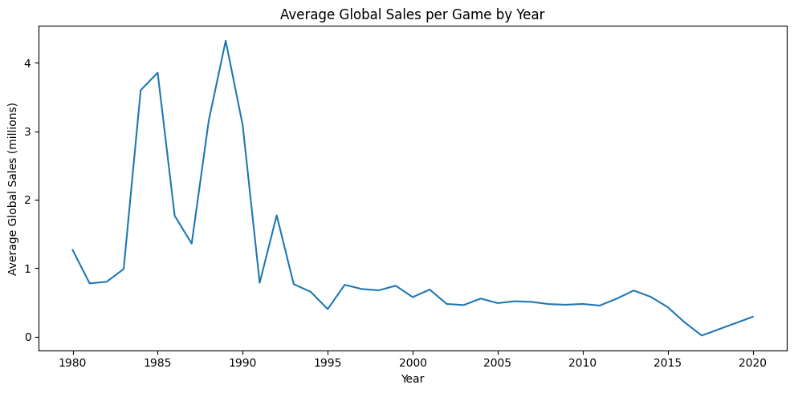

```python
# Plot average sales trend
avg_sales_by_year.plot(figsize=(10,5))
plt.title("Average Global Sales per Game by Year")
plt.xlabel("Year")
plt.ylabel("Average Global Sales (millions)")
plt.tight_layout()
plt.show()
```

Average sales per game do not increase every year but fluctuate. This implies that new games are not necessarily better than old games. This means that competition and market trends are important factors that influence game performance.

**9- What are the characteristics of the top-selling games?**

The company is interested in learning what successful games look like. By examining successful games in terms of sales, it is possible to find similarities in genre, platforms, publishers, or time of release.

```python
# Sort games by global sales and select top 10
top_games = df_clean.sort_values("Global_Sales", ascending=False).head(10)
# Display key information for top-selling games
top_games[["Name", "Platform", "Year", "Genre", "Publisher", "Global_Sales"]]
```

|  | Name | Platform | Year | Genre | Publisher | Global_Sales |
| --- | --- | --- | --- | --- | --- | --- |
| 0 | Wii Sports | Wii | 2006 | Sports | Nintendo | 82.74 |
| 1 | Super Mario Bros. | NES | 1985 | Platform | Nintendo | 40.24 |
| 2 | Mario Kart Wii | Wii | 2008 | Racing | Nintendo | 35.82 |
| 3 | Wii Sports Resort | Wii | 2009 | Sports | Nintendo | 33.00 |
| 4 | Pokemon Red/Pokemon Blue | GB | 1996 | Role-Playing | Nintendo | 31.37 |
| 5 | Tetris | GB | 1989 | Puzzle | Nintendo | 30.26 |
| 6 | New Super Mario Bros. | DS | 2006 | Platform | Nintendo | 30.01 |
| 7 | Wii Play | Wii | 2006 | Misc | Nintendo | 29.02 |
| 8 | New Super Mario Bros. Wii | Wii | 2009 | Platform | Nintendo | 28.62 |
| 9 | Duck Hunt | NES | 1984 | Shooter | Nintendo | 28.31 |

The best-selling games have some common characteristics, including strong platforms, popular genres, and major publishers. This shows that the successful games have a combination of positive factors. Therefore, companies should consider the above trends while planning to release new games.

**10- What business strategy should a company follow when launching a new game?**

The final question integrates all previous results to form a practical recommendation. The objective is not only to present results but to develop a data-driven strategy that a business could implement.

```python
# Identify top-performing genres
top_genres = df_clean.groupby("Genre")["Global_Sales"].sum().sort_values(ascending=False).head(3)
# Identify top-performing platforms
top_platforms = df_clean.groupby("Platform")["Global_Sales"].sum().sort_values(ascending=False).head(3)
# Identify largest regions
top_regions = df_clean[["NA_Sales", "EU_Sales", "JP_Sales"]].sum().sort_values(ascending=False)
# Print summary for strategy decision
print("Top genres:")
print(top_genres)
print("\nTop platforms:")
print(top_platforms)
print("\nRegional market size:")
print(top_regions)
```

```
Top genres:
Genre
Action     1722.84
Sports     1309.24
Shooter    1026.20
Name: Global_Sales, dtype: float64

Top platforms:
Platform
PS2     1233.46
X360     969.60
PS3      949.35
Name: Global_Sales, dtype: float64

Regional market size:
NA_Sales    4327.65
EU_Sales    2406.69
JP_Sales    1284.27
dtype: float64
```

The results indicate that Action, Sports, and Shooter are the top genres, while PS2, X360, and PS3 are the top platforms, and North America is the biggest market. It can therefore be concluded that the best approach is to create games for the top genres, platforms, and target the biggest market, which is North America. However, it should be noted that the results are based on past data and should be used as a guide only.

## Final Discussion & Recommendations

In this notebook, I used the historical video game sales data to answer important business questions for a video game company. From this analysis, it is evident that certain genres and platforms perform better than others in terms of video game sales. Also, it is evident that different geographical areas, such as North America, Europe, and Japan, play different roles in video game sales.

In addition, this analysis proves that publisher strength and platform/genre pairs are key drivers for video game success. Trend analysis for different years gives a broader view of video game trends, and analysis of top-selling video games provides examples of successful video game market trends.

From a business perspective, the main recommendation that can be made is that a business should consider future game development in genres and platforms that have historically performed well while also being aware of regional differences in terms of consumer preferences. However, it should be noted that the results should be taken into account while keeping in mind that the data set being analyzed is historical and does not necessarily reflect the current state of the gaming industry.

In my opinion, The main limitation of this kind of analysis is that it only takes into account sales and does not have any other parameters included in the data set. For future improvements, we can add more data sets to the current one. The project demonstrates how explanatory data analysis can be used to inform business decisions in the gaming industry.

```python
!jupyter nbconvert --to html M504A_Project_Zainab_Awad_Mohammed.ipynb
```

```
[NbConvertApp] Converting notebook M504A_Project_Zainab_Awad_Mohammed.ipynb to html
[NbConvertApp] WARNING | Alternative text is missing on 7 image(s).
[NbConvertApp] Writing 739910 bytes to M504A_Project_Zainab_Awad_Mohammed.html
```